# Human Resource Management: Analysis of Employees Leaving Prematurely

Sanju Jacob Ebey

May 12, 2021

## To check the directory and read the file

```
## [1] "C:/Personal/Capstone"
```

```
## 'data.frame':    14999 obs. of  10 variables:
##  $ satisfaction_level   : num  0.38 0.8 0.11 0.72 0.37 0.41 0.1 0.92 0.89 0.42 ...
##  $ last_evaluation      : num  0.53 0.86 0.88 0.87 0.52 0.5 0.77 0.85 1 0.53 ...
##  $ number_project       : int  2 5 7 5 2 2 6 5 5 2 ...
##  $ average_montly_hours : int  157 262 272 223 159 153 247 259 224 142 ...
##  $ time_spend_company   : int  3 6 4 5 3 3 4 5 5 3 ...
##  $ Work_accident        : int  0 0 0 0 0 0 0 0 0 0 ...
##  $ left                 : int  1 1 1 1 1 1 1 1 1 1 ...
##  $ promotion_last_5years: int  0 0 0 0 0 0 0 0 0 0 ...
##  $ department           : chr  "sales" "sales" "sales" "sales" ...
##  $ salary               : chr  "low" "medium" "medium" "low" ...
```

```
##  satisfaction_level last_evaluation  number_project  average_montly_hours
##  Min.   :0.0900     Min.   :0.3600   Min.   :2.000   Min.   : 96.0
##  1st Qu.:0.4400     1st Qu.:0.5600   1st Qu.:3.000   1st Qu.:156.0
##  Median :0.6400     Median :0.7200   Median :4.000   Median :200.0
##  Mean   :0.6128     Mean   :0.7161   Mean   :3.803   Mean   :201.1
##  3rd Qu.:0.8200     3rd Qu.:0.8700   3rd Qu.:5.000   3rd Qu.:245.0
##  Max.   :1.0000     Max.   :1.0000   Max.   :7.000   Max.   :310.0
##  time_spend_company Work_accident         left        promotion_last_5years
##  Min.   : 2.000     Min.   :0.0000   Min.   :0.0000   Min.   :0.00000
##  1st Qu.: 3.000     1st Qu.:0.0000   1st Qu.:0.0000   1st Qu.:0.00000
##  Median : 3.000     Median :0.0000   Median :0.0000   Median :0.00000
##  Mean   : 3.498     Mean   :0.1446   Mean   :0.2381   Mean   :0.02127
##  3rd Qu.: 4.000     3rd Qu.:0.0000   3rd Qu.:0.0000   3rd Qu.:0.00000
##  Max.   :10.000     Max.   :1.0000   Max.   :1.0000   Max.   :1.00000
##   department           salary
##  Length:14999       Length:14999
##  Class :character   Class :character
##  Mode  :character   Mode  :character
##
##
##
```

## Let's check the correlation values of attributes

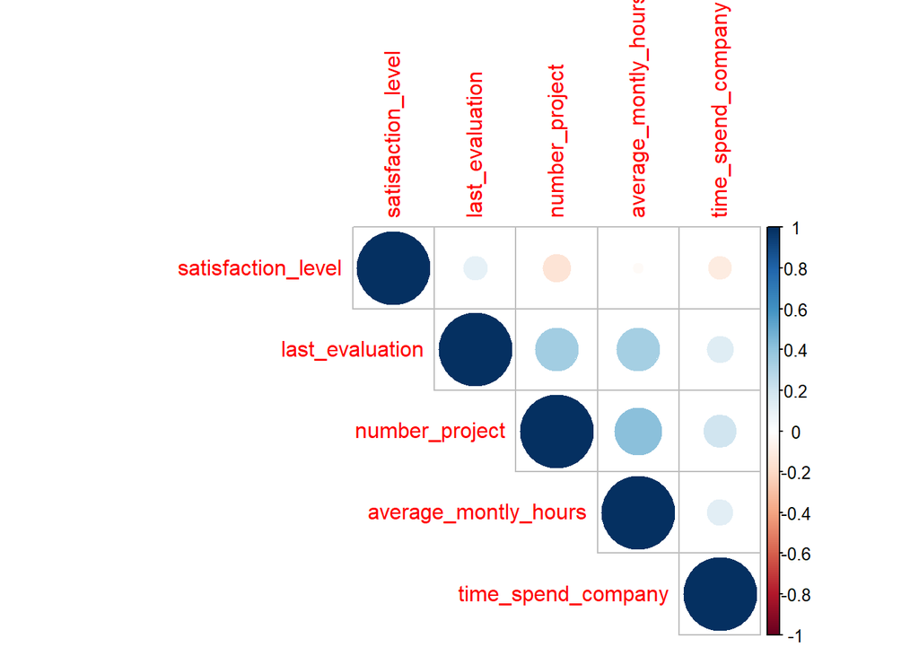

```
##                      satisfaction_level last_evaluation number_project
## satisfaction_level           1.00000000       0.1050212     -0.1429696
## last_evaluation              0.10502121       1.0000000      0.3493326
## number_project              -0.14296959       0.3493326      1.0000000
## average_montly_hours        -0.02004811       0.3397418      0.4172106
## time_spend_company          -0.10086607       0.1315907      0.1967859
##                      average_montly_hours time_spend_company
## satisfaction_level            -0.02004811         -0.1008661
## last_evaluation                0.33974180          0.1315907
## number_project                 0.41721063          0.1967859
## average_montly_hours           1.00000000          0.1277549
## time_spend_company             0.12775491          1.0000000
```

## Let's visualize the datasets for the employees who left the organization

### From the graphs we can realize that majority of the employees left the company because of low salary and low satisfaction level, also employees with lesser number of projects left the company, also the sales department had the maximum number of employees who left the company.

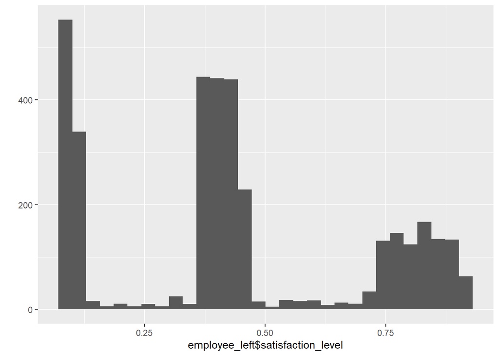

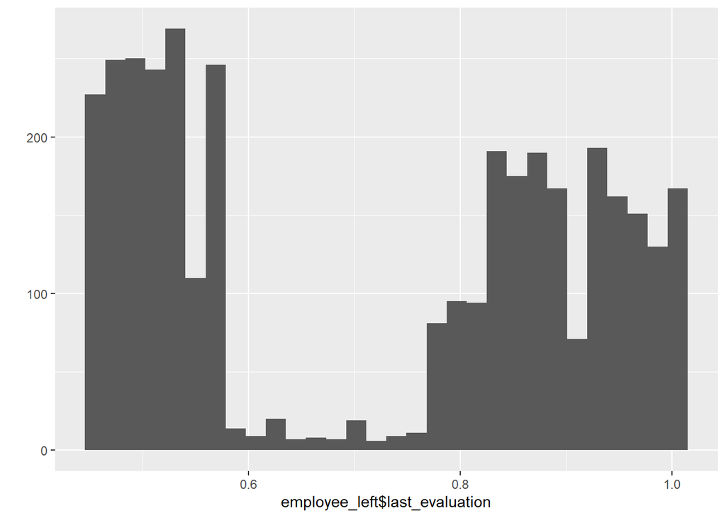

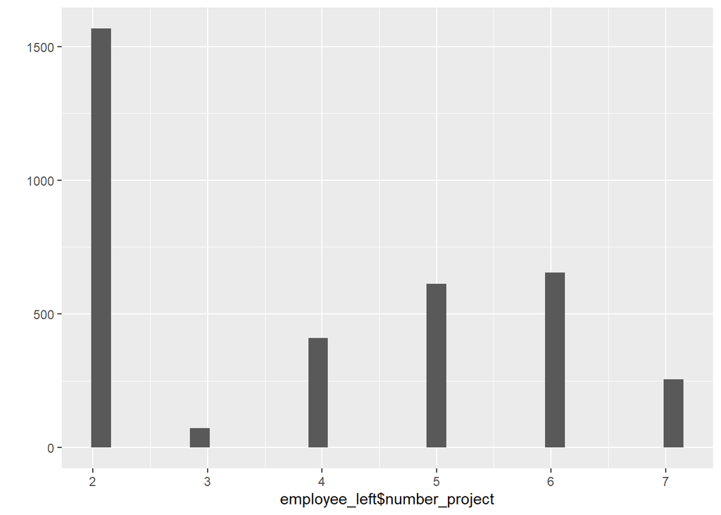

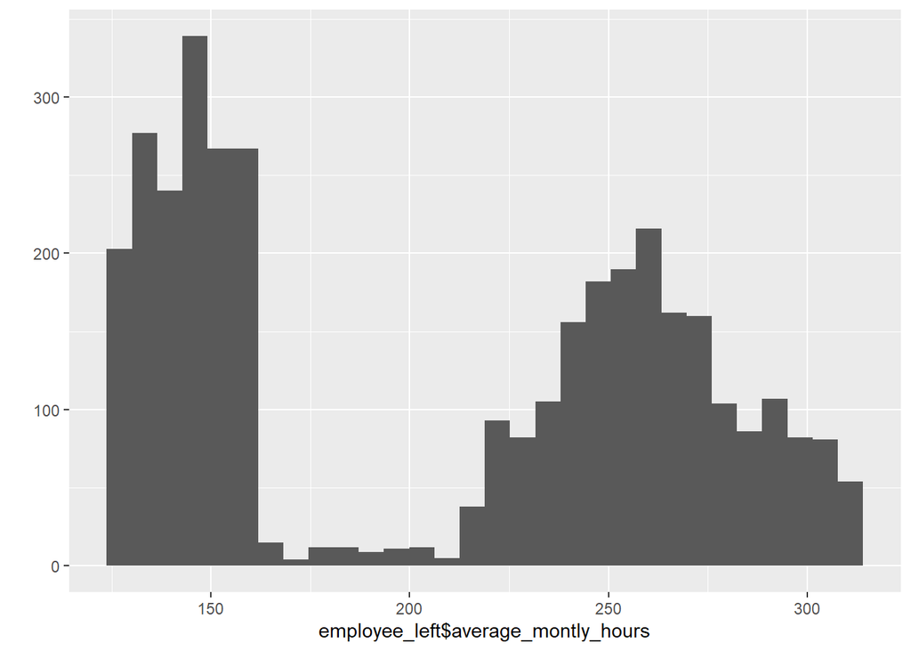

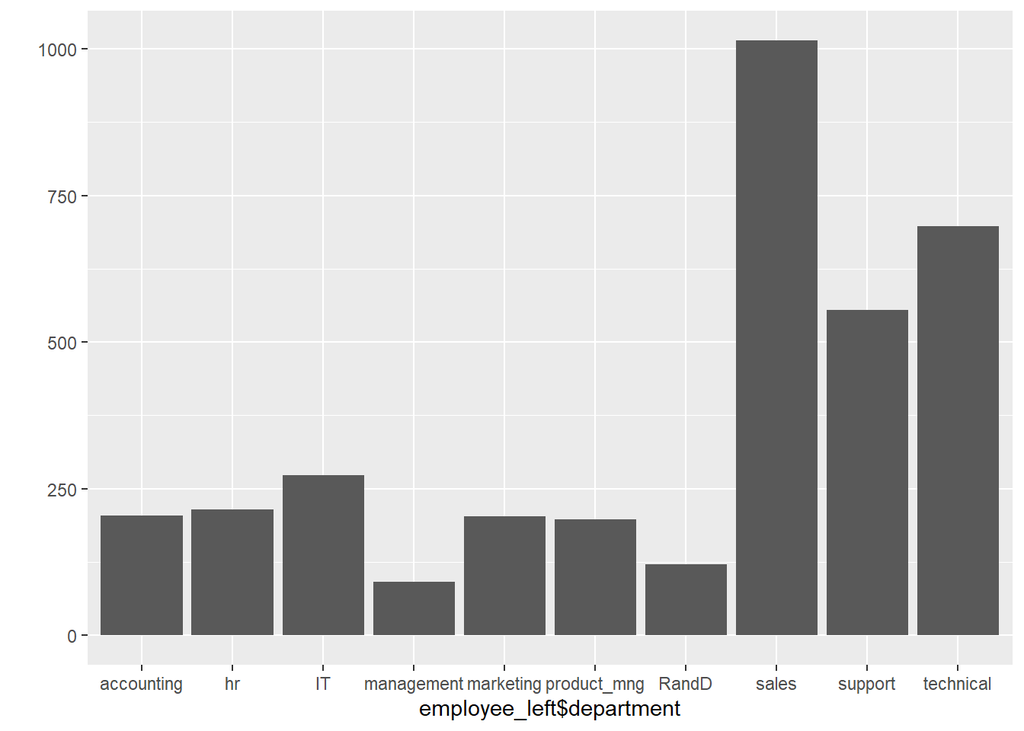

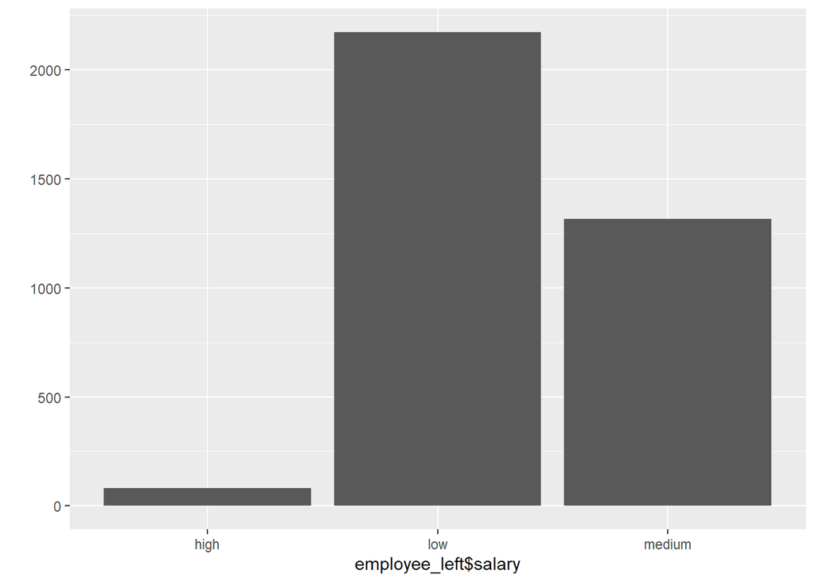

## Let's visualize the relationship between attributes for the employees who left the organization

### From the graphs we could understand that the majority of the employees left the company because-

1. The satisfaction levels were low with some employees having good last evaluation and some with poor last evaluation. Also there were a percentage of employees who left the company with high satisfaction level and good last evaluation.
2. The number of projects done by the employees ranged between moderate and high with the average monthly hours being above the moderate level
3. The satisfaction levels were low with some employees having above moderate average monthly hours and some with low average monthly hours. Also there were a percentage of employees who left the company with above moderate satisfaction level and above moderate average monthly hours.

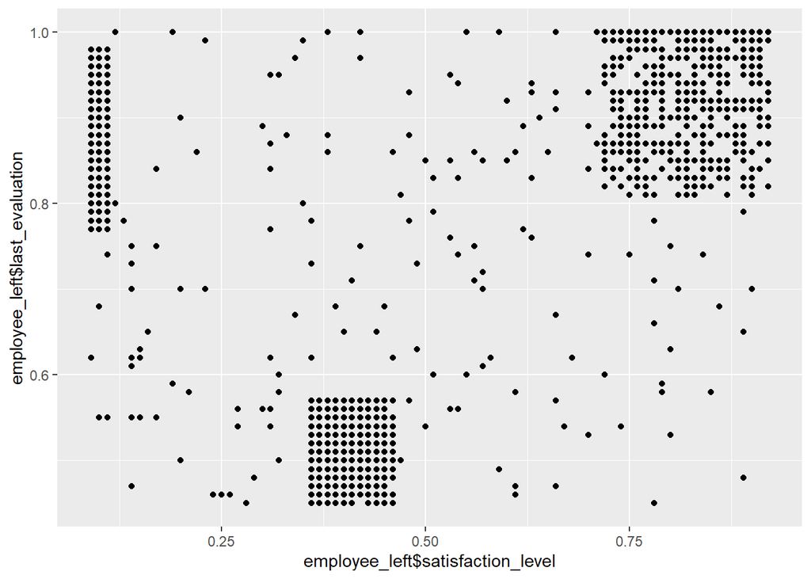

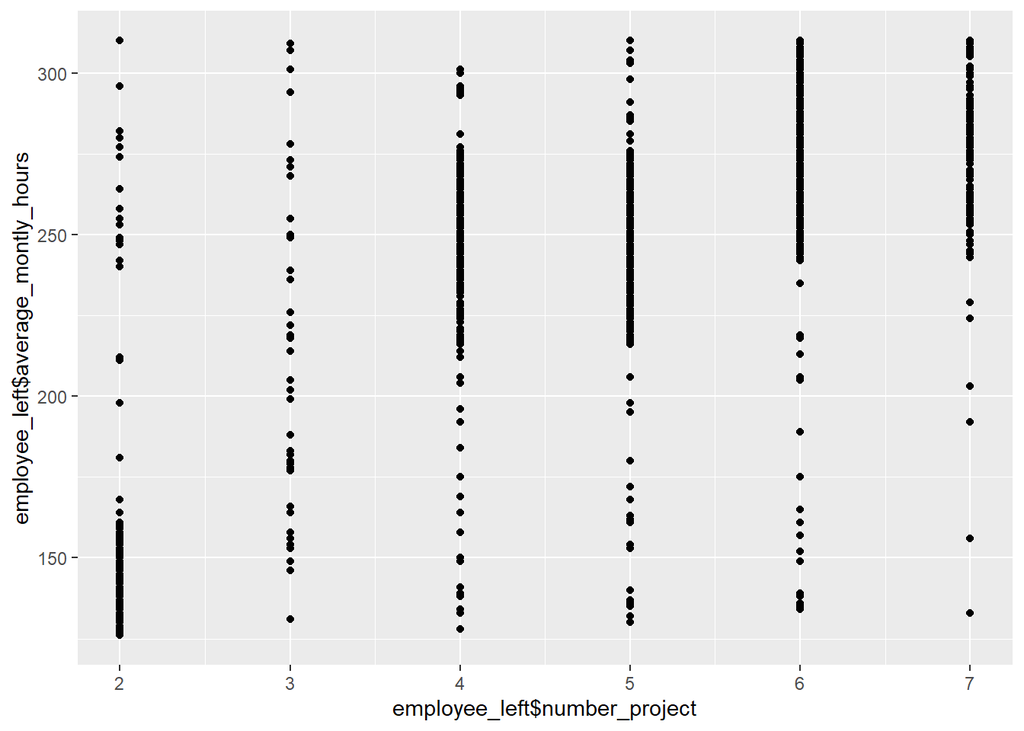

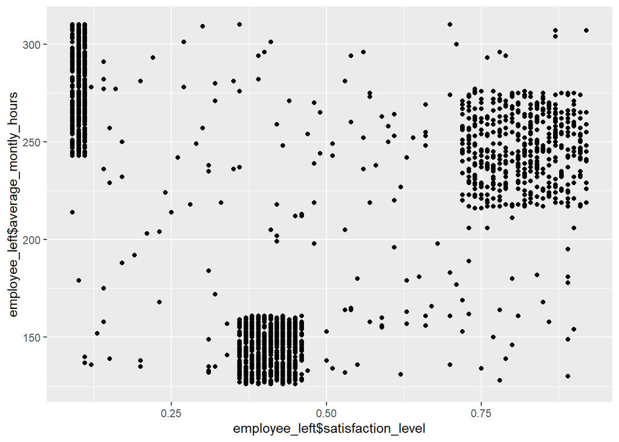

## Let's visualize the datasets for the employees who didn't left the organization

### From the graphs we can realize that majority of the employees who didn't the leave the company had a above moderate satisfaction level and last evaluation. Also the number of projects and average monthly hours were in the moderate range. And the salary was in low or medium category.

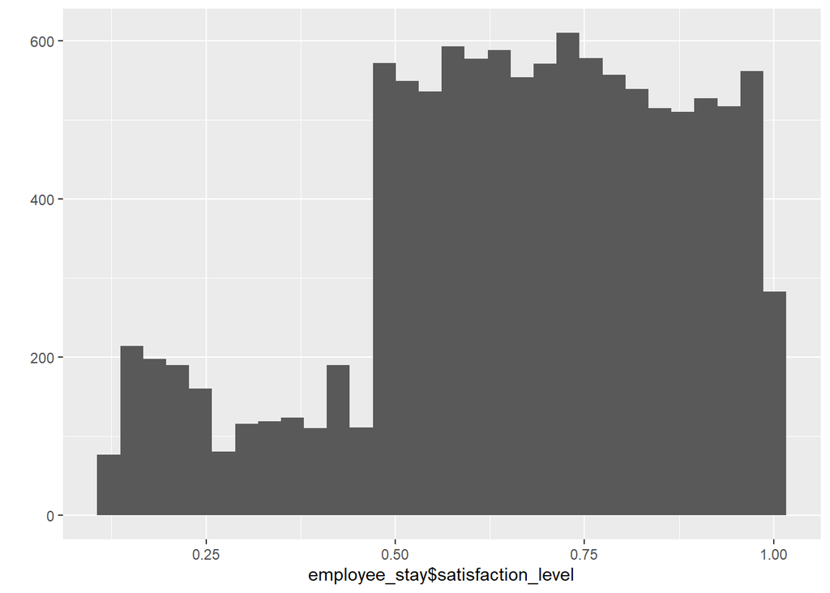

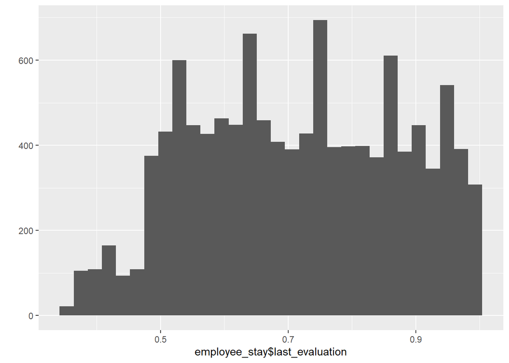

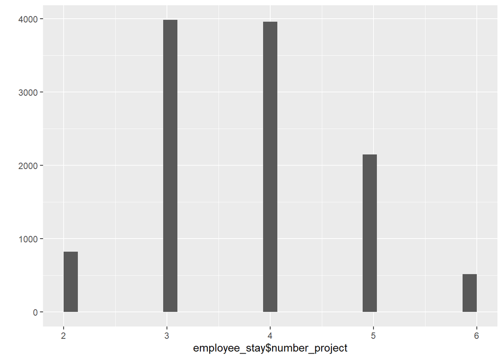

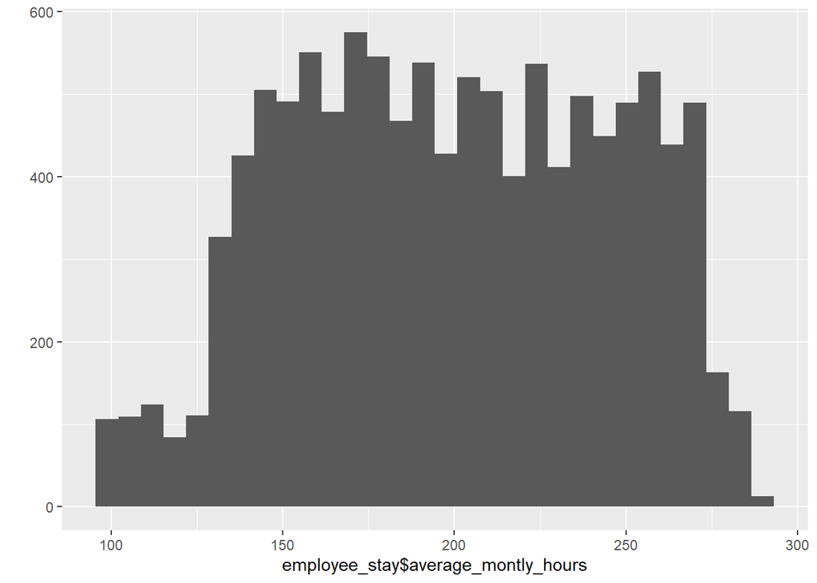

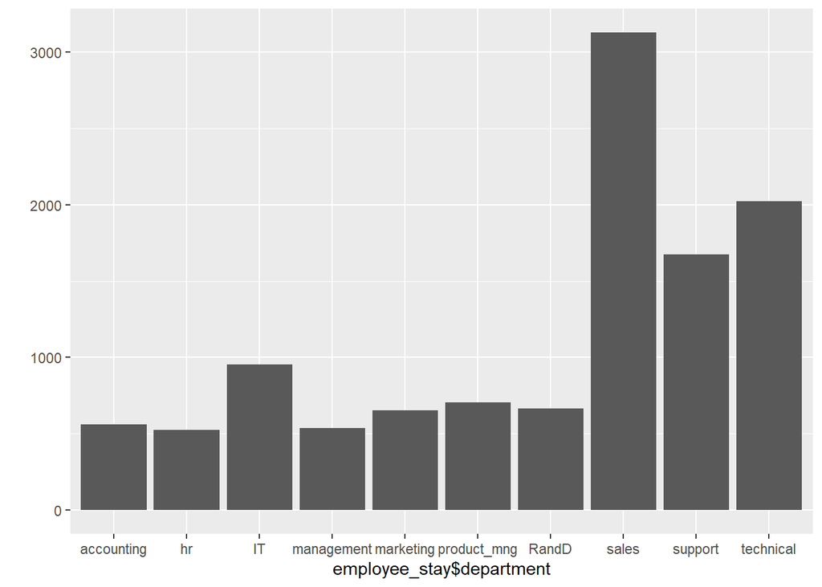

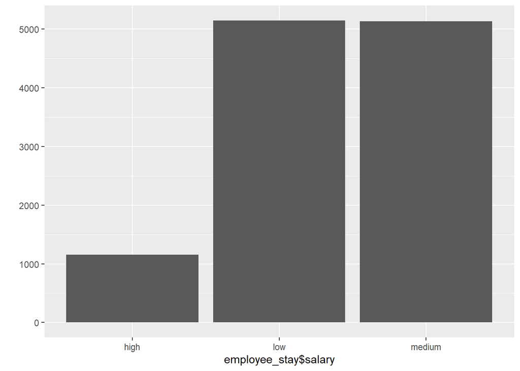

## Let's visualize the relationship between attributes for the employees who didn't left the organization

### From the graphs we could understand that the majority of the employees who didn't leave the company were because -

1. The satisfaction level and the last evaluation were above the moderate level.
2. The number of projects and the average monthly hours varied from low to high.
3. The satisfaction level and average monthly hours were above the moderate level.

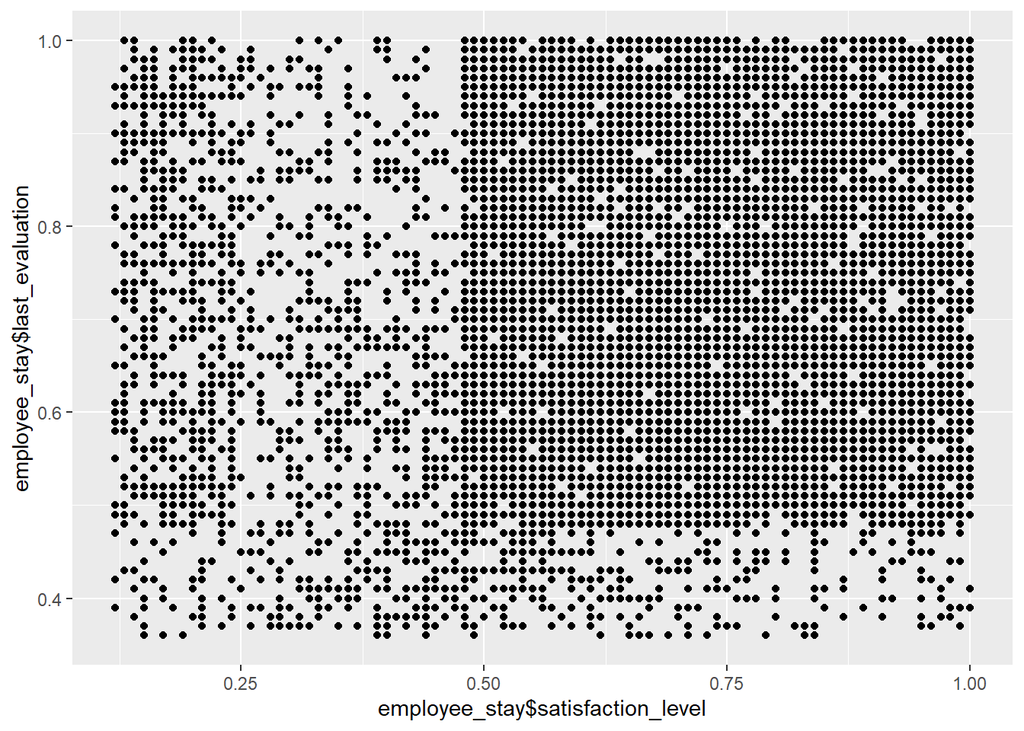

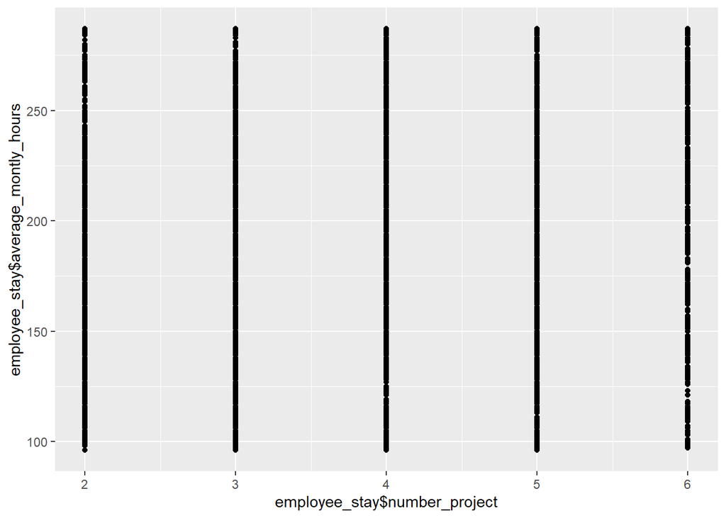

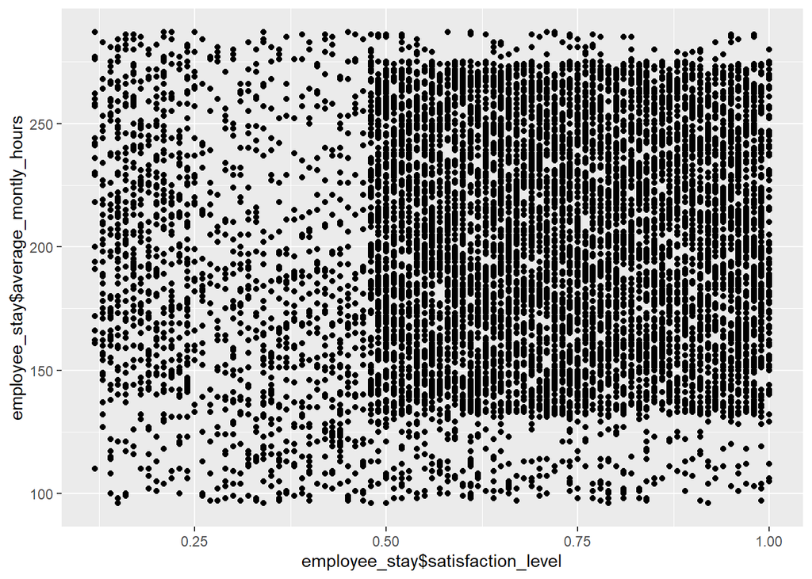

## Let's visualize the datasets for overall employees in the organization

### From the graphs we can understand that the for the majority of the employees in the company,

1. The satisfaction level and last evaluation were in the above moderate level.
2. The number of projects varied from low to moderate level.
3. The average monthly hours varied from moderate to high level.
4. The salary was in the low or medium level.

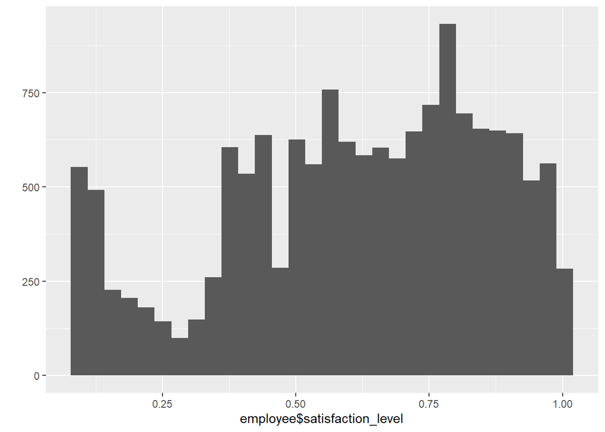

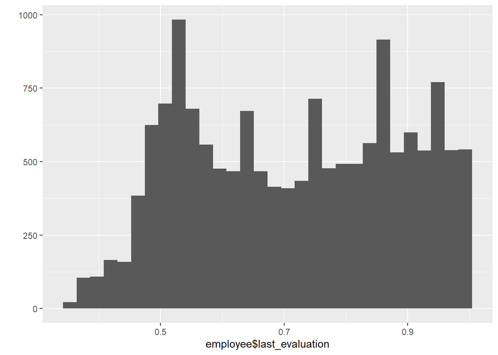

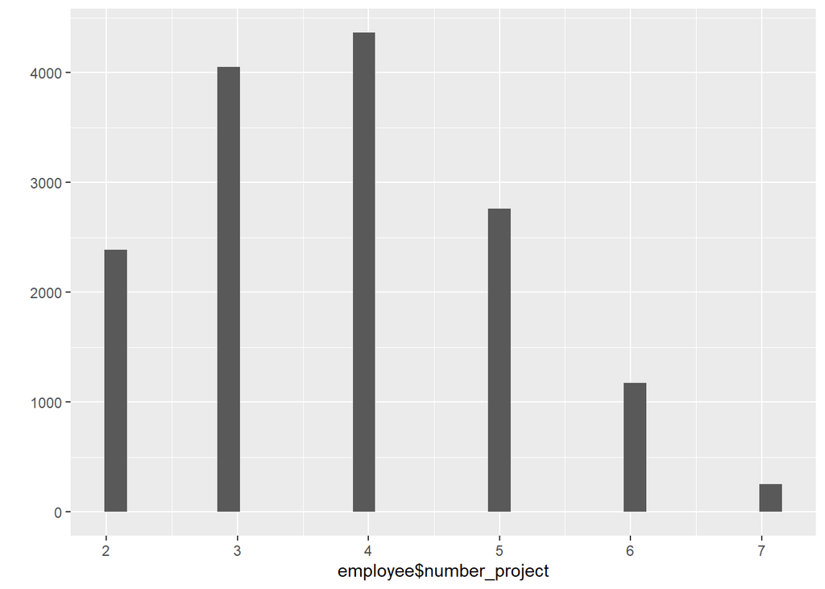

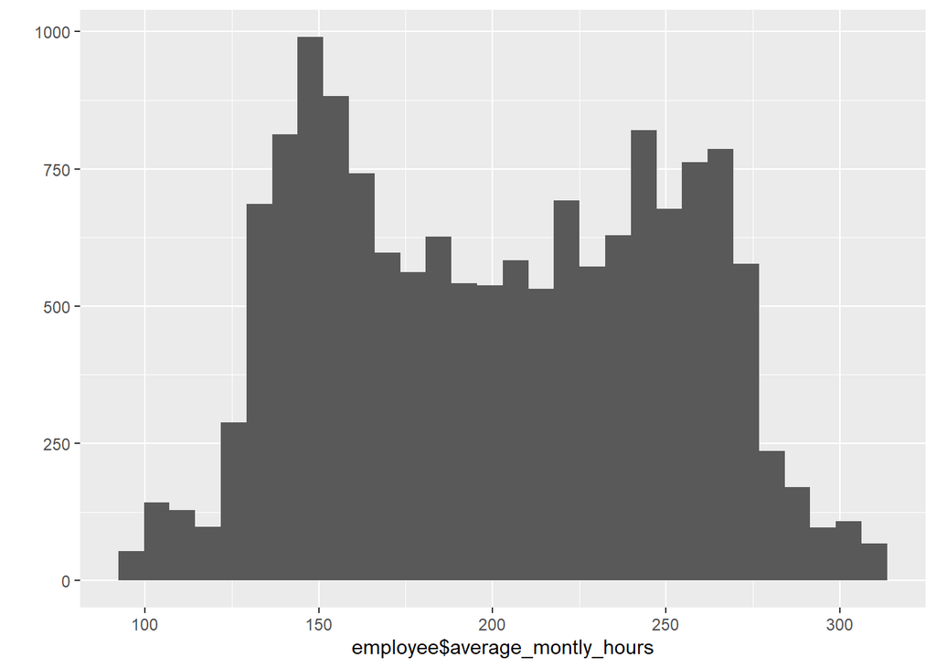

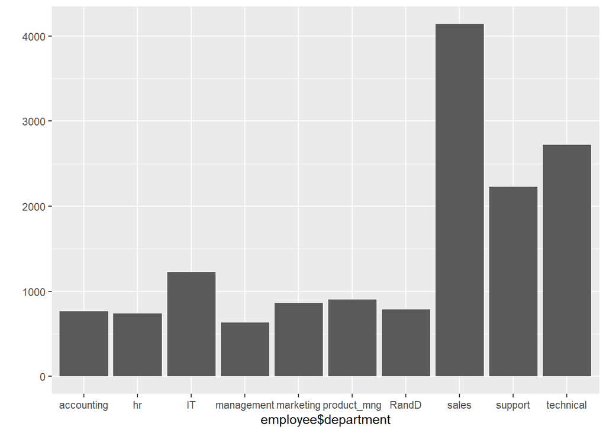

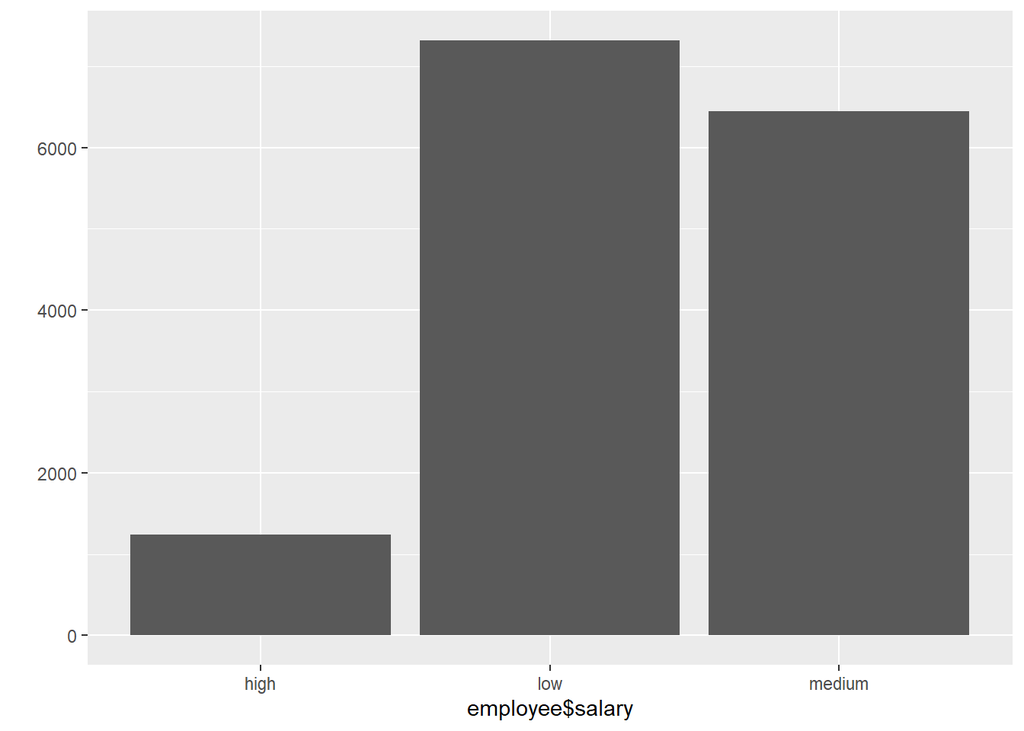

## Let's visualize the relationship between attributes for overall employees

### From the graphs we can understand that for the majority of the employees-

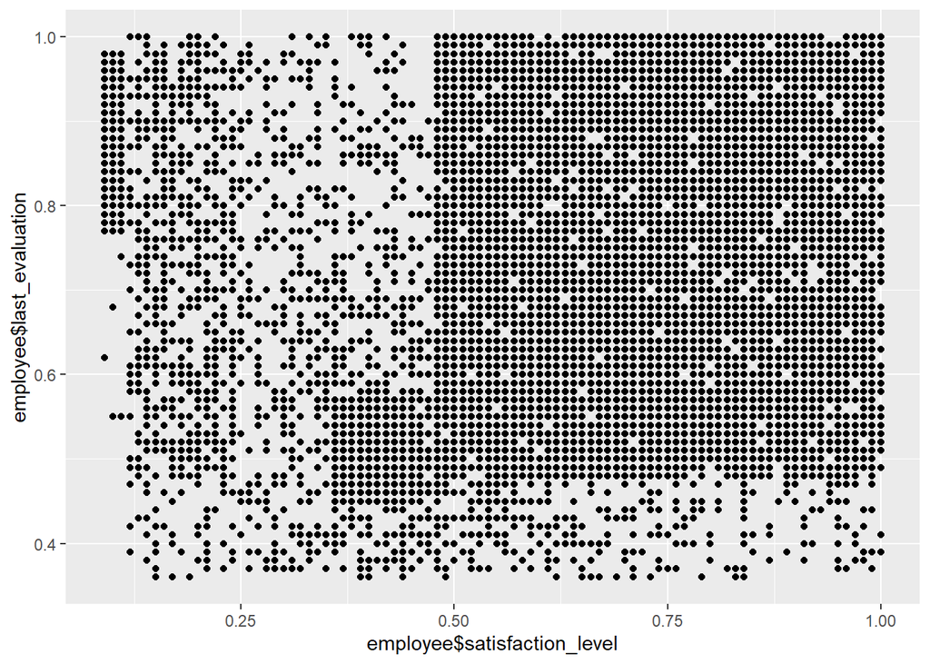

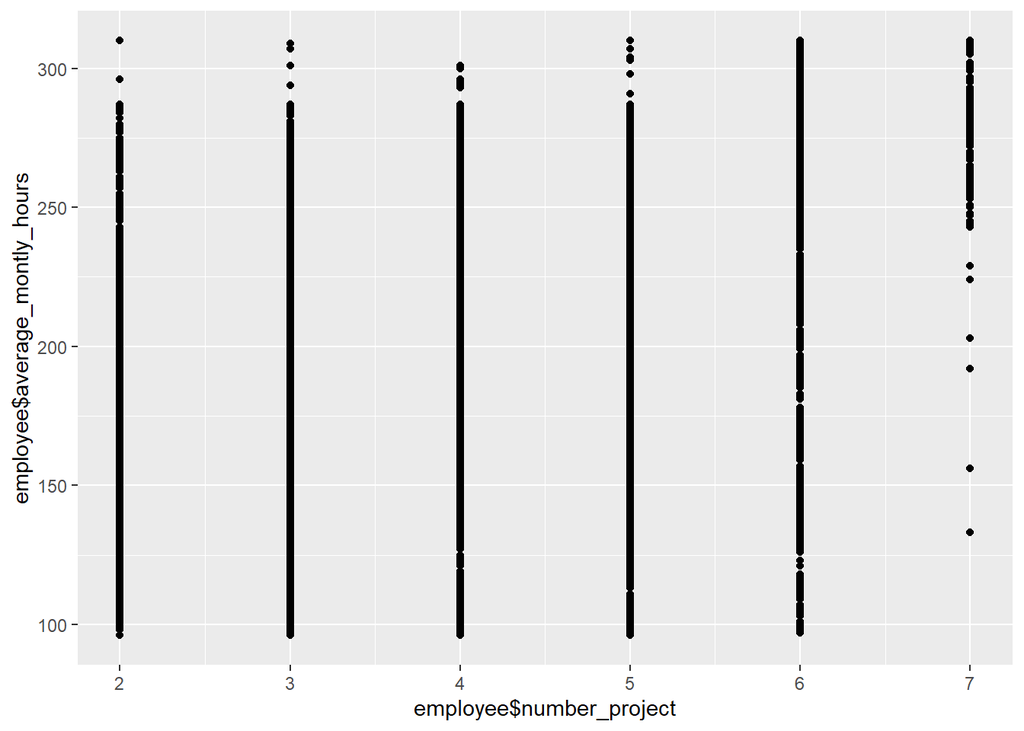

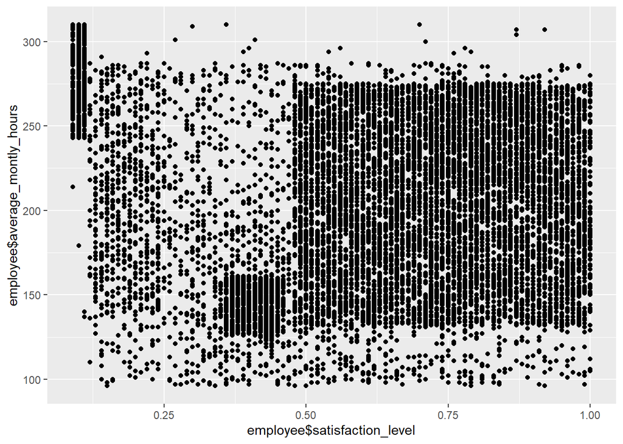

## Let's evaluate department wise turnouts

### From the graphs we can understand that the employees who left the company and who didn't leave the company are the highest for the sales department.

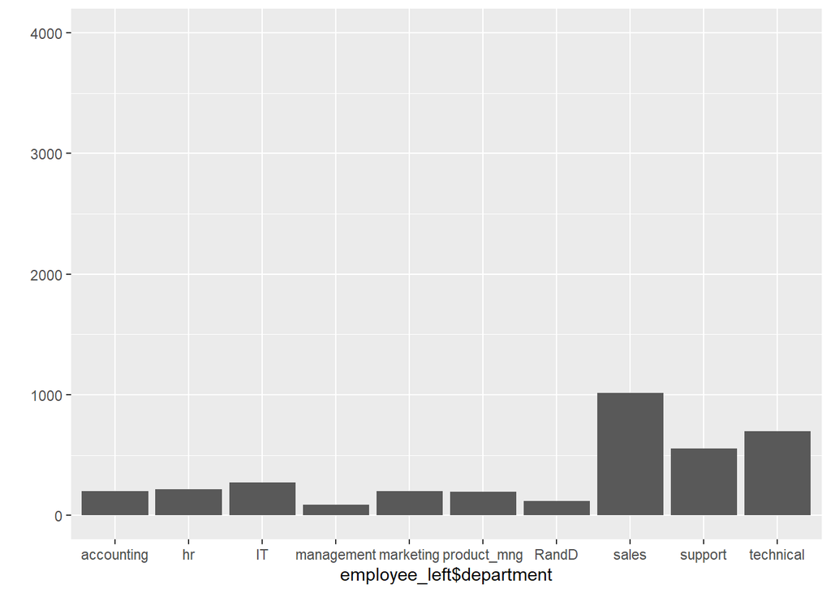

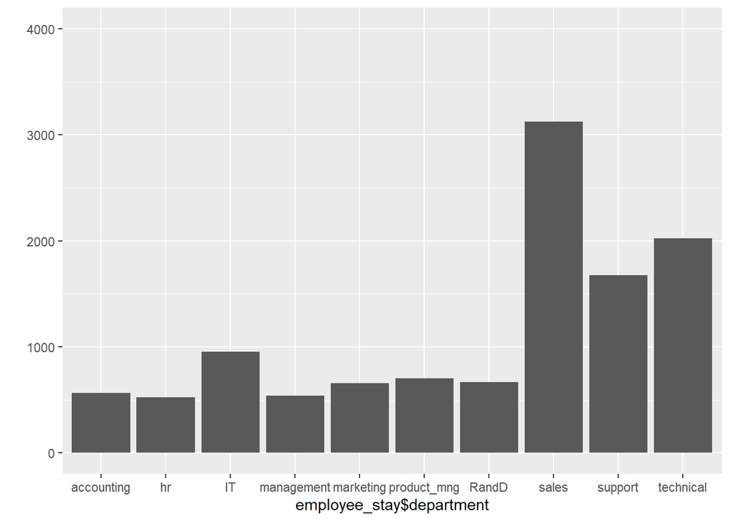

## Let's evaluate percentage of employees leaving from each department

### The highest percentage of employees who left the company was from the HR department and the lowest was from the management department.

```
##             Total_employees Left_employees left_percentage
## accounting              767            204        26.59713
## hr                      739            215        29.09337
## IT                     1227            273        22.24939
## management              630             91        14.44444
## marketing               858            203        23.65967
## product_mng             902            198        21.95122
## RandD                   787            121        15.37484
## sales                  4140           1014        24.49275
## support                2229            555        24.89906
## technical              2720            697        25.62500
```

## Let's start building the first model - Decision tree for this dataset and check the accuracy

```
## 'data.frame':    14999 obs. of  10 variables:
##  $ satisfaction_level   : num  0.38 0.8 0.11 0.72 0.37 0.41 0.1 0.92 0.89 0.42 ...
##  $ last_evaluation      : num  0.53 0.86 0.88 0.87 0.52 0.5 0.77 0.85 1 0.53 ...
##  $ number_project       : int  2 5 7 5 2 2 6 5 5 2 ...
##  $ average_montly_hours : int  157 262 272 223 159 153 247 259 224 142 ...
##  $ time_spend_company   : int  3 6 4 5 3 3 4 5 5 3 ...
##  $ Work_accident        : Factor w/ 2 levels "0","1": 1 1 1 1 1 1 1 1 1 1 ...
##  $ left                 : Factor w/ 2 levels "0","1": 2 2 2 2 2 2 2 2 2 2 ...
##  $ promotion_last_5years: Factor w/ 2 levels "0","1": 1 1 1 1 1 1 1 1 1 1 ...
##  $ department           : Factor w/ 10 levels "accounting","hr",..: 8 8 8 8 8 8 8 8 8 8 ...
##  $ salary               : Factor w/ 3 levels "high","low","medium": 2 3 3 2 2 2 2 2 2 2 ...
```

```
##    satisfaction_level        number_project       last_evaluation
##           2136.891574           1067.240944           1047.350896
##  average_montly_hours    time_spend_company         Work_accident
##           1033.037280            867.600764             25.917490
## promotion_last_5years            department
##             11.111786              3.080599
```

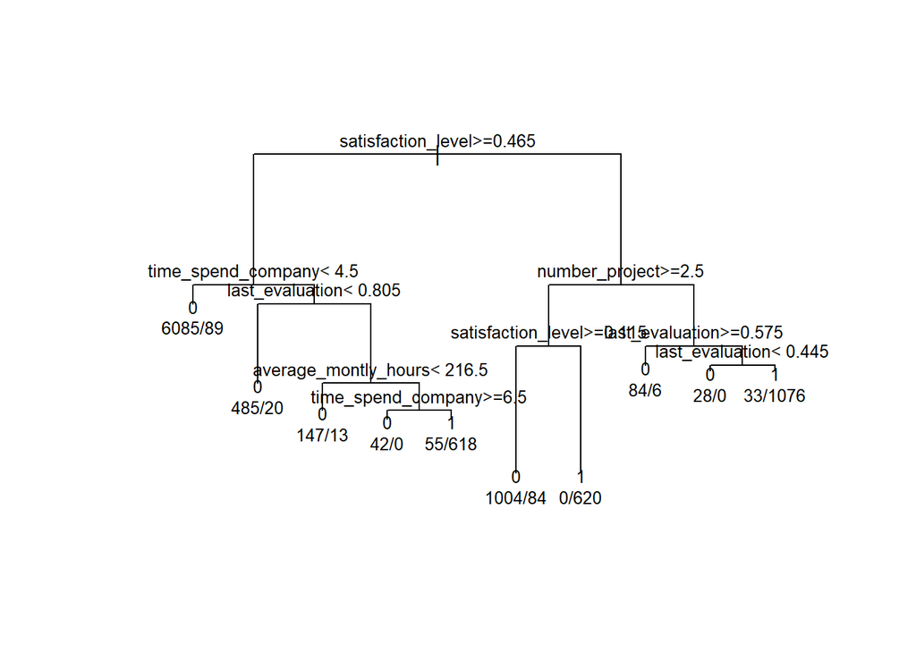

```
## Confusion Matrix and Statistics
##
##
## predvalues    0    1
##          0 3423   90
##          1   42  955
##
##                Accuracy : 0.9707
##                  95% CI : (0.9654, 0.9755)
##     No Information Rate : 0.7683
##     P-Value [Acc > NIR] : < 2.2e-16
##
##                   Kappa : 0.9165
##
##  Mcnemar's Test P-Value : 4.298e-05
##
##             Sensitivity : 0.9879
##             Specificity : 0.9139
##          Pos Pred Value : 0.9744
##          Neg Pred Value : 0.9579
##              Prevalence : 0.7683
##          Detection Rate : 0.7590
##    Detection Prevalence : 0.7789
##       Balanced Accuracy : 0.9509
##
##        'Positive' Class : 0
##
```

## Let's start building the second model - Random Forest for this dataset and check the accuracy

```
##
## Call:
##  randomForest(formula = trainset$left ~ ., data = trainset, ntree = 500)
##                Type of random forest: classification
##                      Number of trees: 500
## No. of variables tried at each split: 3
##
##         OOB estimate of  error rate: 0.87%
## Confusion matrix:
##      0    1 class.error
## 0 7949   14 0.001758131
## 1   77 2449 0.030482977
```

```
## Confusion Matrix and Statistics
##
##
## predvalues    0    1
##          0 3457   37
##          1    8 1008
##
##                Accuracy : 0.99
##                  95% CI : (0.9867, 0.9927)
##     No Information Rate : 0.7683
##     P-Value [Acc > NIR] : < 2.2e-16
##
##                   Kappa : 0.9717
##
##  Mcnemar's Test P-Value : 2.993e-05
##
##             Sensitivity : 0.9977
##             Specificity : 0.9646
##          Pos Pred Value : 0.9894
##          Neg Pred Value : 0.9921
##              Prevalence : 0.7683
##          Detection Rate : 0.7665
##    Detection Prevalence : 0.7747
##       Balanced Accuracy : 0.9811
##
##        'Positive' Class : 0
##
```

```
##                           Overall
## satisfaction_level    1301.985292
## last_evaluation        455.262601
## number_project         691.743443
## average_montly_hours   537.174285
## time_spend_company     710.474630
## Work_accident           20.823248
## promotion_last_5years    4.043871
## department              61.653599
## salary                  30.637282
```

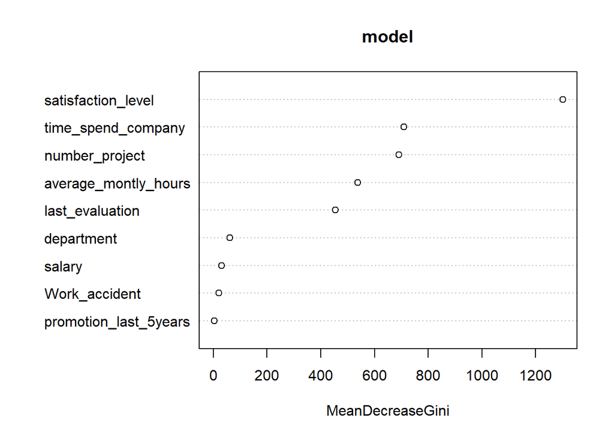

## Let's start building the third model - Naive Bayes for this dataset and check the accuracy

### The accuracy of this model is 84.68% and has a confidence interval ranging from 83.59 to 85.72. We don't consider this model as the accuracy of the prediction is low.

```
##
## Naive Bayes Classifier for Discrete Predictors
##
## Call:
## naiveBayes.default(x = X, y = Y, laplace = laplace)
##
## A-priori probabilities:
## Y
##         0         1
## 0.7591763 0.2408237
##
## Conditional probabilities:
##    satisfaction_level
## Y        [,1]      [,2]
##   0 0.6665114 0.2167399
##   1 0.4411995 0.2640434
##
##    last_evaluation
## Y        [,1]      [,2]
##   0 0.7157692 0.1623760
##   1 0.7181314 0.1977451
##
##    number_project
## Y       [,1]      [,2]
##   0 3.796057 0.9861383
##   1 3.851940 1.8102705
##
##    average_montly_hours
## Y       [,1]     [,2]
##   0 198.9824 45.81035
##   1 207.3476 61.03745
##
##    time_spend_company
## Y       [,1]      [,2]
##   0 3.385533 1.5642649
##   1 3.876485 0.9776641
##
##    Work_accident
## Y            0          1
##   0 0.82481477 0.17518523
##   1 0.95645289 0.04354711
##
##    promotion_last_5years
## Y             0           1
##   0 0.974130353 0.025869647
##   1 0.994853523 0.005146477
##
##    department
## Y   accounting         hr         IT management  marketing product_mng
##   0 0.05199046 0.04684164 0.08464147 0.04709280 0.05651137  0.05977647
##   1 0.05661124 0.06294537 0.07878068 0.02652415 0.05542359  0.05779889
##    department
## Y        RandD      sales    support  technical
##   0 0.05864624 0.27150571 0.14768303 0.17531081
##   1 0.03365004 0.28226445 0.15558195 0.19041964
##
##    salary
## Y         high        low     medium
##   0 0.10184604 0.44957930 0.44857466
##   1 0.02454473 0.60213777 0.37331750
```

```
## Confusion Matrix and Statistics
##
##
## predvalues    0    1
##          0 3212  438
##          1  253  607
##
##                Accuracy : 0.8468
##                  95% CI : (0.8359, 0.8572)
##     No Information Rate : 0.7683
##     P-Value [Acc > NIR] : < 2.2e-16
##
##                   Kappa : 0.5413
##
##  Mcnemar's Test P-Value : 2.565e-12
##
##             Sensitivity : 0.9270
##             Specificity : 0.5809
##          Pos Pred Value : 0.8800
##          Neg Pred Value : 0.7058
##              Prevalence : 0.7683
##          Detection Rate : 0.7122
##    Detection Prevalence : 0.8093
##       Balanced Accuracy : 0.7539
##
##        'Positive' Class : 0
##
```

## Let's start building the fourth model - SVM for this dataset with linear hyperplane and check the accuracy

### The accuracy of this model is 78.18% and has a confidence interval ranging from 76.95 to 79.38. We don't consider this model as the accuracy of the prediction is low.

```
##
## Call:
## svm(formula = trainset$left ~ ., data = trainset, kernel = "linear",
##     cost = 1)
##
##
## Parameters:
##    SVM-Type:  C-classification
##  SVM-Kernel:  linear
##        cost:  1
##
## Number of Support Vectors:  4921
##
##  ( 2453 2468 )
##
##
## Number of Classes:  2
##
## Levels:
##  0 1
```

```
## Confusion Matrix and Statistics
##
##
## predvalues    0    1
##          0 3257  776
##          1  208  269
##
##                Accuracy : 0.7818
##                  95% CI : (0.7695, 0.7938)
##     No Information Rate : 0.7683
##     P-Value [Acc > NIR] : 0.01591
##
##                   Kappa : 0.2436
##
##  Mcnemar's Test P-Value : < 2e-16
##
##             Sensitivity : 0.9400
##             Specificity : 0.2574
##          Pos Pred Value : 0.8076
##          Neg Pred Value : 0.5639
##              Prevalence : 0.7683
##          Detection Rate : 0.7222
##    Detection Prevalence : 0.8942
##       Balanced Accuracy : 0.5987
##
##        'Positive' Class : 0
##
```

## Let's start building the fourth model - SVM for this dataset with polynomial hyperplane and check the accuracy

### The accuracy of this model is 95.23% and has a confidence interval ranging from 94.57 to 95.84. And when it is polynomial hyperplane the accuracy has significantly increased when compared to linear hyperplane.

```
##
## Call:
## svm(formula = trainset$left ~ ., data = trainset, kernel = "polynomial",
##     cost = 1)
##
##
## Parameters:
##    SVM-Type:  C-classification
##  SVM-Kernel:  polynomial
##        cost:  1
##      degree:  3
##      coef.0:  0
##
## Number of Support Vectors:  2064
##
##  ( 1025 1039 )
##
##
## Number of Classes:  2
##
## Levels:
##  0 1
```

```
## Confusion Matrix and Statistics
##
##
## predvalues    0    1
##          0 3349   99
##          1  116  946
##
##                Accuracy : 0.9523
##                  95% CI : (0.9457, 0.9584)
##     No Information Rate : 0.7683
##     P-Value [Acc > NIR] : <2e-16
##
##                   Kappa : 0.8669
##
##  Mcnemar's Test P-Value : 0.2752
##
##             Sensitivity : 0.9665
##             Specificity : 0.9053
##          Pos Pred Value : 0.9713
##          Neg Pred Value : 0.8908
##              Prevalence : 0.7683
##          Detection Rate : 0.7426
##    Detection Prevalence : 0.7645
##       Balanced Accuracy : 0.9359
##
##        'Positive' Class : 0
##
```

## After thorough evaluation we observed that Random Forest is working best in predicting the churn out of employees with overall accuracy of 99% and False positive of 37

## The most important attributes responsible for attrition are -

1. satisfaction_level
2. time_spend_company
3. number_project

## And the least important attributes are,

1. promotion_last_5years
2. work_accident
3. salary